# Final Journalist File

# Updates

## Todo:

- Change folder used for the speech files to original hein-daily so others can more easily run and collaborate on code
- CV.gamlr vs gamlr
- More dummies at the start of file
- Cleaner output
- See which bigrams produced the output
- See what articles they are

## R Best Practices Now Implemented in this code:

Restarting R instead of rm(list=ls()) command.

- Clean R session by restarting, instead of clearing variables in an old session
- *Session > Restart R* or the associated keyboard shortcut Ctrl+Shift+F10 (Windows and Linux) or Command+Shift+F10 (Mac OS).

Instead of setwd()

- Using a R project with a folder containing all the files is much more reproducible and easier to share
- New or Open Project (select a folder)

::Renv to keep track of dependencies:

- Log all packages used so others can easily load and install the required packages

Below is an article that suggests some best practices for writing code in R:

https://www.tidyverse.org/blog/2017/12/workflow-vs-script/

# Setup

```r
# easy loading of packages
library(pacman)
p_load(tidyverse, data.table, tm, quanteda, tokenizers, tidytext, tictoc, gamlr, usethis, Matrix, renv, reactable)

# No scientific notation
options(scipen = 100)

# setting up the working environments
#setwd("/Users/max/Desktop/Journalist Project - Income Dynamics Lab")

# Initialize setting up package dependencies
#renv::init()


# takes a snapshot of package dependencies
renv::snapshot()
```

```
## * Lockfile written to '~/Desktop/Journalist Project - Income Dynamics Lab/renv.lock'.
```

```r
tic("total")

# Generate R file from this R notebook
# knitr::purl("Current_Journalist_R_Notebook.Rmd")
```

# Dummies

```r
# Make y variable a factor or not (Makes no difference)
lasso_y_as_factor = 1

# Speaker or speech level
speaker_level = 1

# Number of files
num_files = 6

# Word Cutoff for the Congressional Speech data i.e. min. number of words in each speech
word_cutoff = 250

# Number of observations used for congress data (needs to be bigger than 3000)
congress_observations = 5000

# Cross_validation?
cross_validated = 1
nfolds_cv = 5

# Number of wapo articles analyzed
wapo_article_size = 1000
```

# Load in Congress data

### Loading in the relevant congressional speech files for creating the X matrix for the LASSO regression

```r
tic("load speech file")
# Earliest speech file needed
earliest_year = 1999

earliest_speech_file <- ((earliest_year - 1981)/2) + 97


cat("The earliest date for the wapo articles is", earliest_speech_file)
```

```
## The earliest date for the wapo articles is 106
```

```r
# Last speech file needed
latest_year = 2015

latest_speech_file <- ((latest_year - 1981)/2) + 97


cat("The latest date for the wapo articles is", latest_speech_file)
```

```
## The latest date for the wapo articles is 114
```

```r
# Loading in the latest congressional speech file from 109 to 114 (I created a folder which contains these files)
# FUTURE UPDATE: code which years and it will automatically select the relevant files

mypath = "/Users/max/Desktop/Journalist Project - Income Dynamics Lab/hein-daily-2005to2015/"
txt_files_ls <- tail(list.files(path="/Users/max/Desktop/Journalist Project - Income Dynamics Lab/hein-daily-2005to2015/", pattern="*.txt"),num_files)

cat("The files used are ", txt_files_ls)
```

```
## The files used are  speeches_109.txt speeches_110.txt speeches_111.txt speeches_112.txt speeches_113.txt speeches_114.txt
```

```r
# Read the files in, assuming comma separator
txt_files_df <- lapply(txt_files_ls, function(x) {read.table(file = paste(mypath,x, sep = ""), header = TRUE, sep ="|", quote = "", fill = TRUE)})
# Combine them

df <- do.call("rbind", lapply(txt_files_df, as.data.frame))

# Single file approach
# df <- read.table("/Users/max/Desktop/Journalist Project - Income Dynamics Lab/hein-daily/speeches_114.txt", header=TRUE, sep="|", quote = "", fill = TRUE)

toc()
```

```
## load speech file: 35.918 sec elapsed
```

# Initial Analysis

### Analyze the dataset of speech files

```r
tic("Speech data analysis")
# find any missing observations
sum(is.na(df))
```

```
## [1] 0
```

```r
# dimensions of the dataframe
dim(df)
```

```
## [1] 939757      2
```

```r
# Find out the number of words of each speech
df$nwords <- str_count(df$speech, "\\w+")
#df$nwords <- sapply(df$speech, function(x) length(unlist(strsplit(as.character(x), "\\W+"))))


cat("The number of speeches with NA as the value is ", sum(is.na(df$nwords)))
```

```
## The number of speeches with NA as the value is  0
```

```r
cat("The number of speeches with 0 words, thus empty is ", length(df$nwords[df$nwords==0]))
```

```
## The number of speeches with 0 words, thus empty is  7
```

```r
as.data.frame(table(cut(df$nwords,breaks=seq(0,2000,by=50))))
```

| Var1 | Freq |
| --- | --- |
| (0,50] | 539333 |
| (50,100] | 56923 |
| (100,150] | 39668 |
| (150,200] | 47403 |
| (200,250] | 37283 |
| (250,300] | 29577 |
| (300,350] | 27169 |
| (350,400] | 23015 |
| (400,450] | 18859 |
| (450,500] | 15489 |

[output cut: 30 more lines]

```r
summary(df$nwords)
```

```
##    Min. 1st Qu.  Median    Mean 3rd Qu.    Max.
##     0.0    11.0    30.0   199.7   227.0 22684.0
```

```r
toc()
```

```
## Speech data analysis: 29.862 sec elapsed
```

Creating a frequency plot

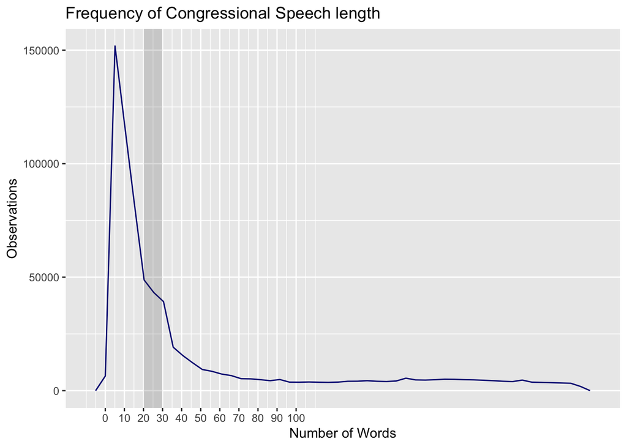

```r
p <- ggplot(df[df$nwords<250,], aes(x = nwords)) +
  geom_freqpoly(bins=50, color = "navyblue") +
  labs(
    title = "Frequency of Congressional Speech length",
    x = "Number of Words",
    y = "Observations"
  )
rect <- data.frame(xmin=20, xmax=30, ymin=-Inf, ymax=Inf)
pp <- p + geom_rect(data=rect, aes(xmin=xmin, xmax=xmax, ymin=ymin, ymax=ymax), color=NA, alpha=0.2, inherit.aes = FALSE)
pp + scale_x_continuous(breaks = seq(0, 100, by = 10))
```

A lot of these observations involve: “and now let’s give the floor to the gentleman from Florida.. etc.” These observations do not contain much political meaning or context and we should thus consider limiting our observations as such

```r
# Lets take the 1st quartile as an example (this is something that could be changed)
#df <- df[df$nwords>11,]
df <- df[df$nwords>word_cutoff,]

# Keep number of words as a separate vector when needed
nwords <- df$nwords

# Subset columns only speech_id and speeches
df <- df[c(1,2)]

# Sampling code that may be useful but will not be executed in this file as of the current version
df <- df[sample(nrow(df),size=congress_observations),]
```

# Congress Speech Bigram Conversion Pt. 1

These steps are very close to the Stanford/Taddy study and the results obtained are similar when comparing the output files.

```r
tic("bigram conversion - until tokens")
# rename columns in order to put them into a corpus object
colnames(df)[colnames(df) == 'speech_id'] <- "doc_id"
colnames(df)[colnames(df) == 'speech'] <- "text"

# (ii) removing apostrophes and replacing commas and semicolons with periods
## removing apostrophes
df$text <- gsub("'", '', df$text)

# replacing commas and semicolons with periods
df$text <- gsub(",", '.', df$text)
df$text <- gsub(":", '.', df$text)

# (iii) replacing repeated white space characters with a single space (if necessary)
df$text <- str_squish(df$text)

# (iv) removing punctuation—hyphens, periods, and asterisks—that separate the article’s demarcation from the actual article
df$text <- gsub('"', '', df$text)
df$text <- gsub('.', '', df$text, fixed = TRUE)
df$text <- gsub('*', '', df$text)
df$text <- gsub('-', '', df$text)

# STEP V removing white spaces at the beginning and end of the speeches
# removes leading and trailing white spaces from the character vectors a.k.a the speeches
df <- df %>%
  mutate(across(where(is.character), str_trim))

corpus <- corpus(df)
tokenz <- tokenizers::tokenize_words(corpus, lowercase = TRUE,) %>%
  tokens(what = "word",remove_punct = TRUE, remove_symbols = TRUE, remove_numbers = FALSE, remove_url = TRUE, remove_separators = TRUE, split_hyphens = TRUE, include_docvars = TRUE, padding = TRUE, verbose = quanteda_options("verbose"), )

toc()
```

```
## bigram conversion - until tokens: 14.064 sec elapsed
```

# Congress Speech Bigram Conversion Pt. 2

```r
tic("bigram conversion - finished")
tokenz[3]
```

```
## Tokens consisting of 1 document.
## 1100022957 :
##  [1] "mr"        "president" "next"      "tuesday"   "will"      "mark"
##  [7] "the"       "start"     "of"        "the"       "fifth"     "year"
## [ ... and 831 more ]
```

```r
tokenz <- tokens_remove(tokenz, pattern = stopwords("en"))
tokenz[3]
```

```
## Tokens consisting of 1 document.
## 1100022957 :
##  [1] "mr"        "president" "next"      "tuesday"   "mark"      "start"
##  [7] "fifth"     "year"      "war"       "iraq"      "nation"    "spent"
## [ ... and 387 more ]
```

```r
tokenz <- tokens_wordstem(tokenz, language = "en")
tokenz[3]
```

```
## Tokens consisting of 1 document.
## 1100022957 :
##  [1] "mr"      "presid"  "next"    "tuesday" "mark"    "start"   "fifth"
##  [8] "year"    "war"     "iraq"    "nation"  "spent"
## [ ... and 387 more ]
```

```r
toks_ngram <- tokens_ngrams(tokenz, n = 2, concatenator = " ")

toks_dfm <- dfm(toks_ngram)

DF <- tidytext::tidy(toks_dfm)
colnames(DF)[colnames(DF) == 'document'] <- "speech_id"

mypath = "/Users/max/Desktop/Journalist Project - Income Dynamics Lab/hein-daily/"
txt_files_ls <- tail(list.files(path="/Users/max/Desktop/Journalist Project - Income Dynamics Lab/hein-daily/", pattern="SpeakerMap.txt"), num_files)

cat("The files used are ", txt_files_ls)
```

```
## The files used are  109_SpeakerMap.txt 110_SpeakerMap.txt 111_SpeakerMap.txt 112_SpeakerMap.txt 113_SpeakerMap.txt 114_SpeakerMap.txt
```

```r
# Read the files in, assuming comma separator
txt_files_df <- lapply(txt_files_ls, function(x) {read.table(file = paste(mypath,x, sep = ""), header = TRUE, sep ="|")})
# Combine them

speaker_map <- do.call("rbind", lapply(txt_files_df, as.data.frame))

# speaker_map <- read.csv("/Users/max/Desktop/Journalist Project - Income Dynamics Lab/hein-daily/114_SpeakerMap.txt", header = TRUE, sep = "|")
DF <-merge(x=DF,y=speaker_map,by="speech_id",all.x=TRUE)
#DF <- DF[c(1:4)]

x <- DF
# x <- DF %>%
#   group_by(speakerid, term) %>%
#   summarise(Frequency = sum(count))

x <- x[complete.cases(x),]
head(x)
```

|  | speech_id | term | count | speakerid | lastname | firstname | chamber | state | gender | party | district | nonvoting |
| --- | --- | --- | --- | --- | --- | --- | --- | --- | --- | --- | --- | --- |
| 1 | 1090000322 | occur region | 1 | 109116700 | BURTON | DAN | H | IN | M | R | 5 | voting |
| 2 | 1090000322 | colleagu gentleman | 1 | 109116700 | BURTON | DAN | H | IN | M | R | 5 | voting |
| 3 | 1090000322 | thank gentleman | 1 | 109116700 | BURTON | DAN | H | IN | M | R | 5 | voting |
| 4 | 1090000322 | help peopl | 3 | 109116700 | BURTON | DAN | H | IN | M | R | 5 | voting |
| 5 | 1090000322 | indonesian govern | 1 | 109116700 | BURTON | DAN | H | IN | M | R | 5 | voting |
| 6 | 1090000322 | short time | 1 | 109116700 | BURTON | DAN | H | IN | M | R | 5 | voting |

```r
toc()
```

```
## bigram conversion - finished: 31.813 sec elapsed
```

```r
# This could be run when wanting to export the files or comparing the Stanford study bigrams to the bigrams created by this file


# bigrams_file <- read.table("/Users/max/Desktop/Journalist Project - Income Dynamics Lab/hein-daily/byspeaker_2gram_114.txt", header=TRUE, sep="|", quote = "", fill = TRUE)
#
# # Rename columns and delete irrelevant columns
# write.csv(x, file ="/Users/max/Desktop/Journalist Project - Income Dynamics Lab/best_bigram_similarity_file.csv")
#
# toc()
```

# Coding our dependent variable

### Here we will code that R = 1 and D = 0.

Changed the code to create the x matrix for speechid instead of speakerid

```r
byspeaker <- x

# Merge with speakermap files in terms
#byspeaker <- byspeaker[c(2,3,4)]
colnames(byspeaker)[colnames(byspeaker) == 'term'] <- "phrase"
colnames(byspeaker)[colnames(byspeaker) == 'Frequency'] <- "count"
#byspeaker <- byspeaker[complete.cases(byspeaker), ]

# create sparse matrix
#byspeaker$speakerid <- factor(byspeaker$speakerid)
#byspeaker$speech_id <- factor(byspeaker$speech_id)
byspeaker$phrase <- factor(byspeaker$phrase)

# byspeaker$speech_id <- factor(byspeaker$speech_id)

str(byspeaker)
```

```
## 'data.frame':    623473 obs. of  12 variables:
##  $ speech_id: chr  "1090000322" "1090000322" "1090000322" "1090000322" ...
##  $ phrase   : Factor w/ 396992 levels "_brave men","_to hear",..: 246155 72344 352728 168006 182908 321822 152777 246198 384974 246111 ...
##  $ count    : num  1 1 1 3 1 1 2 1 1 1 ...
##  $ speakerid: int  109116700 109116700 109116700 109116700 109116700 109116700 109116700 109116700 109116700 109116700 ...
##  $ lastname : chr  "BURTON" "BURTON" "BURTON" "BURTON" ...
##  $ firstname: chr  "DAN" "DAN" "DAN" "DAN" ...
##  $ chamber  : chr  "H" "H" "H" "H" ...
##  $ state    : chr  "IN" "IN" "IN" "IN" ...
##  $ gender   : chr  "M" "M" "M" "M" ...
##  $ party    : chr  "R" "R" "R" "R" ...
##  $ district : int  5 5 5 5 5 5 5 5 5 5 ...
##  $ nonvoting: chr  "voting" "voting" "voting" "voting" ...
```

```r
dim(byspeaker)
```

```
## [1] 623473     12
```

The code chunk above shows that we have successfully created a factor with more levels by using speech_id instead of speaker id

# Creating Sparse Matrix

```r
# X <- sparseMatrix(i = as.numeric(byspeaker$speakerid), j = as.numeric(byspeaker$phrase), x = byspeaker$count, dims = c(nlevels(byspeaker$speakerid), nlevels(byspeaker$phrase)), dimnames = list(id=levels(byspeaker$speakerid), phrase=levels(byspeaker$phrase)))
speakermap <- speaker_map

byspeaker$unique_speech_id <- make.unique(as.character(byspeaker$speech_id) ,sep = ".")
byspeaker <- byspeaker[order(byspeaker$unique_speech_id),]
byspeaker$unique_speech_id <- factor(byspeaker$unique_speech_id)


X <- sparseMatrix(i = as.numeric(byspeaker$unique_speech_id), j = as.numeric(byspeaker$phrase), x = byspeaker$count, dims = c(nlevels(byspeaker$unique_speech_id), nlevels(byspeaker$phrase)), dimnames = list(id=levels(byspeaker$unique_speech_id), phrase=levels(byspeaker$phrase)))


print(object.size(X),units="auto")
```

```
## 79.3 Mb
```

```r
dim(X)
```

```
## [1] 623473 396992
```

[figure not shown]

```r
matrixplot <- image(X)

matrixplot
```

[figure not shown]

```r
# Zoomed in version
image(X[1:400,1:400])
```

```r
# byspeaker$paste <- factor(paste(byspeaker$speech_id, byspeaker$phrase))
# X_test2 <- sparseMatrix(i = as.numeric(byspeaker$paste), j = as.numeric(byspeaker$phrase), x = byspeaker$count, dims = c(nlevels(byspeaker$paste), nlevels(byspeaker$phrase)), dimnames = list(id=levels(byspeaker$paste), phrase=levels(byspeaker$phrase)))
#


# check that it worked
byspeaker[1:5,]
```

|  | speech_id | phrase | count | speakerid | lastname | firstname | chamber | state | gender | party | district | nonvoting | unique_speech_id |
| --- | --- | --- | --- | --- | --- | --- | --- | --- | --- | --- | --- | --- | --- |
| 1 | 1090000322 | occur region | 1 | 109116700 | BURTON | DAN | H | IN | M | R | 5 | voting | 1090000322 |
| 2 | 1090000322 | colleagu gentleman | 1 | 109116700 | BURTON | DAN | H | IN | M | R | 5 | voting | 1090000322.1 |
| 11 | 1090000322 | tonight 150000 | 1 | 109116700 | BURTON | DAN | H | IN | M | R | 5 | voting | 1090000322.10 |
| 101 | 1090000322 | wors best | 1 | 109116700 | BURTON | DAN | H | IN | M | R | 5 | voting | 1090000322.100 |
| 102 | 1090000322 | peopl help | 1 | 109116700 | BURTON | DAN | H | IN | M | R | 5 | voting | 1090000322.101 |

```r
X[1,as.numeric(byspeaker$phrase)[1:5]]
```

```
##       occur region colleagu gentleman     tonight 150000          wors best
##                  1                  0                  0                  0
##         peopl help
##                  0
```

```r
#rm(byspeaker)


# speakermap <- read.table("hein-daily/114_SpeakerMap.txt", sep="|", header=T)


# speakermap <- speaker_map
#
#
#
# speakermap$name <- paste(speakermap$firstname, speakermap$lastname) # one name
# speakermap <- speakermap[!duplicated(speakermap$speakerid),c("speakerid","party", "name")] # drop irrelevant cols
# speakermap <- speakermap[order(speakermap[,1]),] # sort by id

# drop ids not in X
drop_these_ids <- as.integer(setdiff(as.character(factor(byspeaker$unique_speech_id)),row.names(X)))
byspeaker <- byspeaker[!(byspeaker$speakerid %in% drop_these_ids),]

# Merge to have a speaker id for each speech_id

# check that ids in X and speakermap line up
if (sum(!(row.names(X)==as.character(factor(byspeaker$unique_speech_id)))) != 0) { print("Recheck code: ids are not aligned.")}
```

```r
# Bernie Sanders and Angus King both seem to be Democrat leaning thus we will change their values to D
byspeaker$party[byspeaker$name == "BERNARD SANDERS"] <-"D"
byspeaker$party[byspeaker$name == "ANGUS KING"] <-"D"
byspeaker$party[byspeaker$name == "GREGORIO SABLAN"] <-"D"
# This can be checked later to see if there are any other congressmen that need to be recoded in terms of their political party
byspeaker$party[byspeaker$party == "I"] <-"D"
#speakermap$party <- factor(speakermap$party)
table(byspeaker$party)
```

```
##
##      D      R
## 322056 301417
```

```r
# lasso with raw counts
if (lasso_y_as_factor == 0) {
cat(" ")
cat(" ")
cat("Party variable will be converted to factor")
cat(" ")
cat(" ")
byspeaker$party <- factor(byspeaker$party)
head(byspeaker$party)
} else {
byspeaker$party <- ifelse(byspeaker$party == "R", 1,0)
cat(" ")
cat(" ")
cat("Manually coded for R = 1 and D = 0")
cat(" ")
cat(" ")
head(byspeaker$party)
}
```

```
##   Manually coded for R = 1 and D = 0
```

```
## [1] 1 1 1 1 1 1
```

```r
str(byspeaker)
```

```
## 'data.frame':    623473 obs. of  13 variables:
##  $ speech_id       : chr  "1090000322" "1090000322" "1090000322" "1090000322" ...
##  $ phrase          : Factor w/ 396992 levels "_brave men","_to hear",..: 246155 72344 360994 392780 261400 195724 260934 154058 348088 384142 ...
##  $ count           : num  1 1 1 1 1 1 1 1 1 1 ...
##  $ speakerid       : int  109116700 109116700 109116700 109116700 109116700 109116700 109116700 109116700 109116700 109116700 ...
##  $ lastname        : chr  "BURTON" "BURTON" "BURTON" "BURTON" ...
##  $ firstname       : chr  "DAN" "DAN" "DAN" "DAN" ...
##  $ chamber         : chr  "H" "H" "H" "H" ...
##  $ state           : chr  "IN" "IN" "IN" "IN" ...
##  $ gender          : chr  "M" "M" "M" "M" ...
##  $ party           : num  1 1 1 1 1 1 1 1 1 1 ...
##  $ district        : int  5 5 5 5 5 5 5 5 5 5 ...
##  $ nonvoting       : chr  "voting" "voting" "voting" "voting" ...
##  $ unique_speech_id: Factor w/ 623473 levels "1090000322","1090000322.1",..: 1 2 3 4 5 6 7 8 9 10 ...
```

# Cross-Validated LASSO Regression

```r
# y <- speakermap$party
y <- byspeaker$party

if (cross_validated==1) {
lassoslant <- cv.gamlr(X,y, nfold = nfolds_cv, verb = TRUE , select="1se")
plot(lassoslant)
B <- coef(lassoslant, select="1se")[-1, ]
cat("Using cv.gamlr function with cross-validation")
} else {
lassoslant <- gamlr(X, y) # use AICc for speed
plot(lassoslant)
B <- coef(lassoslant)[-1, ]
cat("Using gamlr function with AICc (no cross-validation)")
}
```

```
## fold 1,2,3,4,5,done.
```

```
## Using cv.gamlr function with cross-validation
```

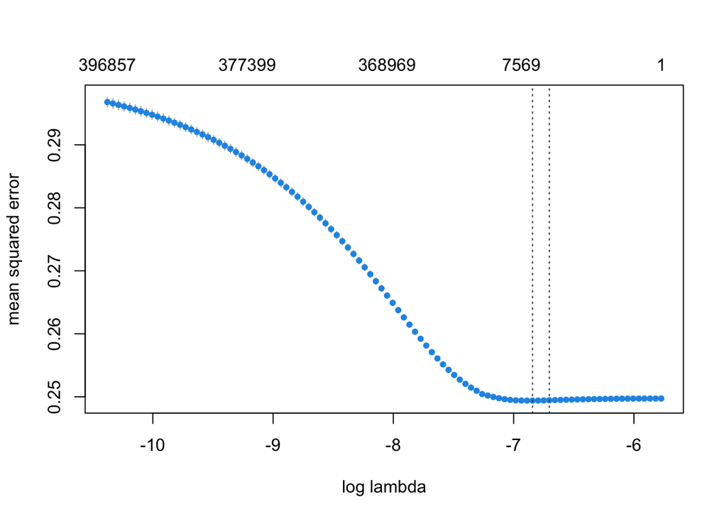

```r
#lassoslant <- gamlr(X, y) # use AICc for speed
#lassoslant <- cv.gamlr(X,y, nfold = nfolds_cv, verb = TRUE , select="1se")
plot(lassoslant)
```

```r
B <- coef(lassoslant, select="1se")[-1, ]
head(sort(round(B[B != 0], 4))) # nonzero coefficients
```

```
##    vulner popul     cut benefit    live poverti program program       work bill
##         -0.2148         -0.1772         -0.1702         -0.1689         -0.1668
##    question can
##         -0.1606
```

```r
tail(sort(round(B[B != 0], 4)))
```

```
## kill american  certain want    peopl keep      sure get     said cant
##        0.1508        0.1709        0.1740        0.1740        0.1936
##  listen debat
##        0.1975
```

```r
coefficients_lasso2 <- data.frame(as.list(sort(round(B[B != 0], 4)))) # nonzero coefficients
#write.csv(coefficients_lasso2, file ="/Users/max/Desktop/Journalist Project - Income Dynamics Lab/lasso_coefficients.csv")
names(sort(B)[1:10]) # Low repshare (Dems)
```

```
##  [1] "vulner popul"    "cut benefit"     "live poverti"    "program program"
##  [5] "work bill"       "question can"    "repres district" "year republican"
##  [9] "children receiv" "ten million"
```

```r
names(sort(-B)[1:10]) # High repshare (Repubs)
```

```
##  [1] "listen debat"  "said cant"     "sure get"      "peopl keep"
##  [5] "certain want"  "kill american" "actual get"    "tax penalti"
##  [9] "secur countri" "know there"
```

```r
# lasso with proportions
x_prop <- X/rowSums(X)
lassoslant_prop <- gamlr(x_prop, y)
B_prop <- coef(lassoslant_prop)[-1, ]
sort(round(B_prop[B_prop != 0], 4))
```

```
##          black caucus     congression black republican leadership
##               -0.2283               -0.2283               -0.1830
##           middl class        bush administr   republican colleagu
##               -0.1756               -0.1753               -0.1489
##           walter reed          live poverti              find job
##               -0.1475               -0.1357               -0.1323
##           civil right          vulner popul      african american
##               -0.1311               -0.1225               -0.1177
##             right act           credit card             work bill
##               -0.1151               -0.1129               -0.1129
##              war iraq         30someth work       program program
##               -0.1082               -0.1078               -0.1078
##          minimum wage       repres district               tax cut
##               -0.1039               -0.0956               -0.0944
##       children receiv        nutrit program             tax break
##               -0.0911               -0.0911               -0.0852
##            opposit hr      million children           also provid
##               -0.0849               -0.0817               -0.0809
##        import protect     republican leader           weapon mass
##               -0.0808               -0.0808               -0.0808
##       year republican            thank much          climat chang
##               -0.0797               -0.0758               -0.0744
##             amend act           barbara lee        critic program
##               -0.0719               -0.0719               -0.0719
##           cut benefit       democrat caucus            dog coalit
##               -0.0719               -0.0719               -0.0719
##           colleg educ        consum protect     republican friend
##               -0.0656               -0.0656               -0.0656
##        amend committe           ten million     district columbia
##               -0.0642               -0.0642               -0.0632
##           work famili      million american         join colleagu
##               -0.0619               -0.0610               -0.0601
##             work hard             go colleg           drink water
##               -0.0533               -0.0512               -0.0502
##         sexual orient          deni coverag             lost home
##               -0.0497               -0.0496               -0.0496
##          question can        redeploy troop              act 2007
##               -0.0496               -0.0496               -0.0479
##          program help              blue dog        unemploy insur
##               -0.0479               -0.0456               -0.0456
```

[output cut: 123 more lines]

```
##                0.0710                0.0784                0.0784
##            actual get             articl ii         kill american
##                0.0824                0.0824                0.0824
##              mr obama             said cant                tax go
##                0.0824                0.0824                0.0830
##            part world             death tax         stimulus bill
##                0.0840                0.0970                0.0984
##           increas tax          tax american           tax increas
##                0.1022                0.1136                0.1159
##       american energi            harri reid           job creator
##                0.1257                0.1284                0.1383
##          listen debat              rais tax       individu mandat
##                0.1406                0.1551                0.1553
##          govern spend        democrat major
##                0.1613                0.1712
```

```r
names(sort(B_prop)[1:10]) # Low repshare (Dems)
```

```
##  [1] "congression black"     "black caucus"          "republican leadership"
##  [4] "middl class"           "bush administr"        "republican colleagu"
##  [7] "walter reed"           "live poverti"          "find job"
## [10] "civil right"
```

```r
names(sort(-B_prop)[1:10]) # High repshare (Repubs)
```

```
##  [1] "democrat major"  "govern spend"    "individu mandat" "rais tax"
##  [5] "listen debat"    "job creator"     "harri reid"      "american energi"
##  [9] "tax increas"     "tax american"
```

```r
# plot AICc curves
# ll <- log(lassoslant$lambda) # the sequence of lambdas
# ll <- log(lassoslant$lambda.1se) # the sequence of lambdas
# # plot(ll, AICc(lassoslant)/length(y), xlab = "log lambda", ylab = "AICc/n", pch = 21, bg = "orange")
# plot(ll, AICc(lassoslant$lambda.1se)/length(y), xlab = "log lambda", ylab = "AICc/n", pch = 21, bg = "orange")
# abline(v = ll[which.min(AICc(lassoslant))], col = "orange", lty = 3)
# abline(v = ll[which.min(AICc(lassoslant_prop))], col = "black", lty = 3)
# points(ll, AICc(lassoslant_prop)/length(y), pch = 21, bg = "black")
# legend("topright", bty = "n", fill = c("black", "orange"), legend = c("lassoslant", "lassoslant_prop"))



# Prediction

coefficients_lasso <- pivot_longer(coefficients_lasso2, cols = everything(), names_to = "phrase",  values_to = "coefficient")
coefficients_lasso$phrase <- gsub('X', '', coefficients_lasso$phrase)
coefficients_lasso$phrase <- gsub('X', '', coefficients_lasso$phrase)
coefficients_lasso$phrase <- gsub('[[:punct:] ]+',' ',coefficients_lasso$phrase)
coefficients_lasso$phrase <- trimws(coefficients_lasso$phrase, which = c("both"))

# number of coefficients
length(coefficients_lasso2)
```

```
## [1] 1787
```

```r
reactable(coefficients_lasso)
```

| phrase | coefficient |
| --- | --- |
| vulner popul | -0.2148 |
| cut benefit | -0.1772 |
| live poverti | -0.1702 |
| program program | -0.1689 |
| work bill | -0.1668 |
| question can | -0.1606 |
| repres district | -0.1577 |
| year republican | -0.156 |
| children receiv | -0.1555 |
| ten million | -0.1532 |

[output cut: 1777 more lines]

```r
#rm(df,toks_dfm,toks_ngram,DF,x,X,x_prop)
```

# Coefficient Table

Remember that R=1 and D=0

```r
htmltools::tagList(
  reactable::reactable(coefficients_lasso)
)
```

| phrase | coefficient |
| --- | --- |
| vulner popul | -0.2148 |
| cut benefit | -0.1772 |
| live poverti | -0.1702 |
| program program | -0.1689 |
| work bill | -0.1668 |
| question can | -0.1606 |
| repres district | -0.1577 |
| year republican | -0.156 |
| children receiv | -0.1555 |
| ten million | -0.1532 |

[output cut: 1777 more lines]

# Washington Post Bigrams

Now we will create the bigrams from the wapo articles and apply our LASSO coefficients to make a prediction

First we will load in and subset the WAPO articles to the relevant timerange e.g. cut out the 1931 observation

```r
wapo <- fread('/Users/max/Desktop/Journalist Project - Income Dynamics Lab/wapo_articles.csv')


wapo <- wapo[rev(order(as.Date(wapo$V4, format="%Y/%m/%d"))),]

head(wapo[,4])
```

| V4 |
| --- |
| 2020-05-11 |
| 2019-11-05 |
| 2019-08-06 |
| 2019-07-11 |
| 2019-07-11 |
| 2019-07-11 |

```r
tail(wapo[,4])
```

| V4 |
| --- |
| 2005-03-22 |
| 2005-03-22 |
| 2005-03-22 |
| 2005-03-22 |
| 2005-03-22 |
| 1931-08-22 |

```r
wapo <- wapo[wapo$V4 <= "2015-12-31",]
wapo <- wapo[wapo$V4 > "2004-12-31",]

head(wapo[,4])
```

| V4 |
| --- |
| 2015-11-08 |
| 2015-11-06 |
| 2015-11-05 |
| 2015-11-04 |
| 2015-11-03 |
| 2015-11-02 |

```r
tail(wapo[,4])
```

| V4 |
| --- |
| 2005-03-22 |
| 2005-03-22 |
| 2005-03-22 |
| 2005-03-22 |
| 2005-03-22 |
| 2005-03-22 |

```r
wapo <- rename(wapo, speech=V5)

wapo$index <- 1:nrow(wapo)
head(wapo)
```

| V1 | V2 | V3 | V4 | speech | index |
| --- | --- | --- | --- | --- | --- |
| https://www.washingtonpost.com/national/the-fixs-week-in-politics/2015/11/08/a5e1d2c0-8659-11e5-be8b-1ae2e4f50f76_story.html | The Fix\x92s week in politics |  | 2015-11-08 | QUOTE OF THE WEEK \x93I don\x92t like what he did, and I think it hurt the president having his iron-ass view of everything.\x94 Former president George H.W. Bush, in a biography out this week, critic… | 1 |
| https://www.washingtonpost.com/national/six-killed-as-bus-carrying-migrant-farmworkers-crashes-in-arkansas/2015/11/06/1ee8b324-81b3-11e5-9afb-0c971f713d0c_story.html | Six killed as bus carrying migrant farmworkers crashes in Arkansas |  | 2015-11-06 | Arkansas Bus crash kills 6 migrant farmworkers A bus ferrying migrant farmworkers from Michigan to Texas ran off a highway and hit an overpass in Arkansas on Friday, ripping off the roof and ejecting … | 2 |
| https://www.washingtonpost.com/national/digest/2015/11/05/f394d752-81b2-11e5-9afb-0c971f713d0c_story.html | Pa. police officer is acquitted in fatal shooting of unarmed motorist |  | 2015-11-05 | Attendees listen as President Obama speaks at the annual White House Tribal Nations Conference in Washington. The conference focused on ways to empower Native American youth. (Jonathan Ernst/Reuters) … | 3 |
| https://www.washingtonpost.com/national/keystone-xl-oil-pipeline-will-not-be-granted-a-pause-white-house-says/2015/11/04/9c23b18c-81b2-11e5-9afb-0c971f713d0c_story.html | Keystone XL oil pipeline will not be granted a pause, White House says |  | 2015-11-04 | ENERGY Obama says no delay on Keystone decision The Obama administration said Wednesday that it will not delay its verdict on the fate of the Keystone XL oil pipeline, in a new signal that President O… | 4 |
| https://www.washingtonpost.com/national/national-roundup-florida-reports-backlog-of-testing-on-rape-kits/2015/11/03/607c6c00-81b2-11e5-9afb-0c971f713d0c_story.html | National roundup: Florida reports backlog of testing on rape kits |  | 2015-11-03 | FLORIDA Untested rape kits number 10,900 Nearly 11,000 rape kits have not been tested in Florida, according to statistics released by the state Tuesday, mirroring backlogs at law enforcement agencies … | 5 |
| https://www.washingtonpost.com/national/national-roundup-cargo-ship-found-under-15000-feet-of-water-in-atlantic/2015/11/02/c2bbf67a-819d-11e5-9afb-0c971f713d0c_story.html | National roundup: Cargo ship found under 15,000 feet of water in Atlantic | Ashley Halsey Iii, Reporter Covering National Transportation, Paul Kane, May, Ashley Halsey Reported On National Transportation, Including Infrastructure, Aviation, Autonomous Cars, Shipping. He Left … | 2015-11-02 | By Ashley Halsey III and Ashley Halsey III Reporter covering national transportation Email Bio Follow \x97 Paul Kane May 19, 2010 atlantic ocean Ship lost in storm is 15,000 feet under A Navy search t… | 6 |

```r
wapo_original <- wapo
wapo <- wapo[,c(5,6)]

wapo <- wapo[sample(nrow(wapo),size=wapo_article_size),]
```

```r
tic("wapo bigram conversion - until tokens")
# rename columns in order to put them into a corpus object
colnames(wapo)[colnames(wapo) == 'index'] <- "doc_id"
colnames(wapo)[colnames(wapo) == 'speech'] <- "text"

# (ii) removing apostrophes and replacing commas and semicolons with periods
## removing apostrophes
wapo$text <- gsub("'", '', wapo$text)

# replacing commas and semicolons with periods
wapo$text <- gsub(",", '.', wapo$text)
wapo$text <- gsub(":", '.', wapo$text)

# (iii) replacing repeated white space characters with a single space (if necessary)
wapo$text <- str_squish(wapo$text)

# (iv) removing punctuation—hyphens, periods, and asterisks—that separate the article’s demarcation from the actual article
wapo$text <- gsub('"', '', wapo$text)
wapo$text <- gsub('.', '', wapo$text, fixed = TRUE)
wapo$text <- gsub('*', '', wapo$text)
wapo$text <- gsub('-', '', wapo$text)

# STEP V removing white spaces at the beginning and end of the speeches
# removes leading and trailing white spaces from the character vectors a.k.a the speeches
wapo <- wapo %>%
  mutate(across(where(is.character), str_trim))

corpus <- corpus(wapo)
tokenz <- tokenizers::tokenize_words(corpus, lowercase = TRUE,) %>%
  tokens(what = "word",remove_punct = TRUE, remove_symbols = TRUE, remove_numbers = FALSE, remove_url = TRUE, remove_separators = TRUE, split_hyphens = TRUE, include_docvars = TRUE, padding = TRUE, verbose = quanteda_options("verbose"), )

toc()
```

```
## wapo bigram conversion - until tokens: 1.919 sec elapsed
```

```r
tic("wapo bigram conversion - finished")
tokenz[3]
```

```
## Tokens consisting of 1 document.
## 446133 :
##  [1] "i"         "spent"     "tuesday"   "afternoon" "driving"   "down"
##  [7] "to"        "mountain"  "view"      "calif"     "about"     "30"
## [ ... and 1,121 more ]
```

```r
tokenz <- tokens_remove(tokenz, pattern = stopwords("en"))
tokenz[3]
```

```
## Tokens consisting of 1 document.
## 446133 :
##  [1] "spent"     "tuesday"   "afternoon" "driving"   "mountain"  "view"
##  [7] "calif"     "30"        "40"        "minutes"   "drive"     "south"
## [ ... and 656 more ]
```

```r
tokenz <- tokens_wordstem(tokenz, language = "en")
tokenz[3]
```

```
## Tokens consisting of 1 document.
## 446133 :
##  [1] "spent"     "tuesday"   "afternoon" "drive"     "mountain"  "view"
##  [7] "calif"     "30"        "40"        "minut"     "drive"     "south"
## [ ... and 656 more ]
```

```r
toks_ngram <- tokens_ngrams(tokenz, n = 2, concatenator = " ")

toks_dfm <- dfm(toks_ngram)

DF <- tidytext::tidy(toks_dfm)
colnames(DF)[colnames(DF) == 'document'] <- "index"


wapo_bigrams <- DF %>%
  group_by(index, term) %>%
  summarise(count = sum(count))
colnames(wapo_bigrams)[colnames(wapo_bigrams) == 'term'] <- "phrase"

wapo_bigrams <- wapo_bigrams[complete.cases(wapo_bigrams),]

toc()
```

```
## wapo bigram conversion - finished: 4.424 sec elapsed
```

```r
# wapo_bigrams <- read.csv("wapo_max_bigrams_1000.csv", header = TRUE, sep = ",")

# Aggregates counts by index (representing a news article) and by phrase as subgroups, essentially merging duplicates and adding the count of the merged phrase
# wapo_bigrams <- wapo_bigrams %>%
#   group_by(index, phrase) %>%
#   summarise(count = sum(count))

#matches <- plyr::match_df(coefficients_lasso, wapo_bigrams, on = "phrase")

# match
matches <- wapo_bigrams[which(wapo_bigrams$phrase %in% coefficients_lasso$phrase),]
matches <- matches[order(matches$index),]

# test <- matches[matches$index==unique(matches$index),]
test <- matches
  #test[nrow(test) + 1,] = list(test$index[1],"thank famili",33)

  #test
#index_no <- test[,1]


#test <- test[c(2,3)]
# Create a new data frame with the dimension and rownames (which we will turn into column names) as the coefficient matrix/vector
match <- coefficients_lasso
match$coefficient <- 0
colnames(match)[colnames(match) == 'coefficient'] <- "count"

# make the matrix vector into wide format 1 * n vector
#match <- match %>% pivot_wider(names_from = phrase, values_from = count)
# if there is a match then fill row with count otherwise leave as 0

match <- merge(x=match,y=test,by="phrase",all.x=TRUE)
match$count.y <- ifelse(is.na(match$count.y)==TRUE, 0, match$count.y)

colnames(match)[colnames(match) == 'count.y'] <- "count"

# Save the index to attach later
index_matches <- match$index

# take out wrong count column (wrong since it is a byproduct of the merge)
match <- match[-c(2)]
look2 <- match %>% pivot_wider(names_from = phrase, values_from = count)

# Drop if index number = NA
look3 <- look2[!is.na(look2$index),]

# now we have our count dataframe
look4 <- mutate_all(look3, ~replace(., is.na(.), 0))

# save the index
multiplication_index <- look4$index

#remove index from data frame
look5 <- look4[-c(1)]

result <- data.matrix(look5) %*% as.numeric(coefficients_lasso2)

# convert logit coefficients intepreted as log odds to probabilities
logit_func <- function(x) {
   exp(x)/(1+exp(x))
}
result <- logit_func(result)

result <- cbind(multiplication_index, result)
head(order(result))
```

```
## [1] 732 662 669 674 680 677
```

```r
tail(order(result))
```

```
## [1]  92 537 538  76 454 283
```

```r
# Build function to include what article and what bigrams produced the result

toc()
```

```
## total: 232.155 sec elapsed
```

# Results

```r
# wapo_bigrams <- read.csv("wapo_max_bigrams_1000.csv", header = TRUE, sep = ",")

# Aggregates counts by index (representing a news article) and by phrase as subgroups, essentially merging duplicates and adding the count of the merged phrase
# wapo_bigrams <- wapo_bigrams %>%
#   group_by(index, phrase) %>%
#   summarise(count = sum(count))

#matches <- plyr::match_df(coefficients_lasso, wapo_bigrams, on = "phrase")

# match
matches <- wapo_bigrams[which(wapo_bigrams$phrase %in% coefficients_lasso$phrase),]
matches <- matches[order(matches$index),]

test <- matches[matches$index==unique(matches$index),]
  #test[nrow(test) + 1,] = list(test$index[1],"thank famili",33)

  #test
#index_no <- test[,1]


#test <- test[c(2,3)]
# Create a new data frame with the dimension and rownames (which we will turn into column names) as the coefficient matrix/vector
match <- coefficients_lasso
match$coefficient <- 0
colnames(match)[colnames(match) == 'coefficient'] <- "count"

# make the matrix vector into wide format 1 * n vector
#match <- match %>% pivot_wider(names_from = phrase, values_from = count)
# if there is a match then fill row with count otherwise leave as 0

match <-merge(x=match,y=test,by="phrase",all.x=TRUE)
match$count.y <- ifelse(is.na(match$count.y)==TRUE, 0, match$count.y)

colnames(match)[colnames(match) == 'count.y'] <- "count"

# Save the index to attach later
index_matches <- match$index

# take out wrong count column (wrong since it is a byproduct of the merge)
match <- match[-c(2)]
look2 <- match %>% pivot_wider(names_from = phrase, values_from = count)

# Drop if index number = NA
look3 <- look2[!is.na(look2$index),]

# now we have our count dataframe
look4 <- mutate_all(look3, ~replace(., is.na(.), 0))

# save the index
multiplication_index <- look4$index

#remove index from data frame
look5 <- look4[-c(1)]

result <- data.matrix(look5) %*% as.numeric(coefficients_lasso2)

# convert logit coefficients intepreted as log odds to probabilities
logit_func <- function(x) {
   exp(x)/(1+exp(x))
}
result <- logit_func(result)

result <- cbind(multiplication_index, result)
result

reactable(result)

toc()
```

# Results Table

```r
htmltools::tagList(
  reactable::reactable(result)
)
```

| multiplication_index | V2 |
| --- | --- |
| 85385 | 0.454476419914007 |
| 351357 | 0.468790626626244 |
| 505025 | 0.486328408715981 |
| 293659 | 0.457552419163818 |
| 516424 | 0.480260265239345 |
| 145663 | 0.458396414047405 |
| 284312 | 0.487027911681522 |
| 325213 | 0.461203144983809 |
| 352935 | 0.461203144983809 |
| 445025 | 0.461203144983809 |

[output cut: 640 more lines]

# Test: Attach Bigrams

```r
matches2 <- matches

aaa <- aggregate(paste(matches2$phrase,matches2$count, sep = "; ")~matches2$index, matches2, FUN= paste, collapse=' ')

colnames(aaa)[colnames(aaa)=='matches2$index'] <- 'multiplication_index'

results2 <- data.frame(result)

bbb <- left_join(results2, aaa, by="multiplication_index")

colnames(bbb)[3] <- 'phrases'
```

```r
htmltools::tagList(
  reactable::reactable(bbb)
)
```

| multiplication_index | V2 | phrases |
| --- | --- | --- |
| 85385 | 0.454476419914007 | 10 12; 1 new york; 1 |
| 351357 | 0.468790626626244 | 10 12; 1 11 12; 1 dont know; 1 dont think; 5 georg washington; 2 im go; 1 mani time; 1 matter much; 1 north carolina; 1 peopl told; 1 pretti good; 2 said think; 1 state that; 1 state think; 1 year thi… |
| 505025 | 0.486328408715981 | 11 12; 1 one recent; 1 two decad; 1 |
| 293659 | 0.457552419163818 | 11 12; 1 |
| 516424 | 0.480260265239345 | 16 billion; 1 govern go; 1 presid bush; 1 presid said; 1 price fuel; 1 |
| 145663 | 0.458396414047405 | 16 billion; 1 |
| 284312 | 0.487027911681522 | 160 million; 1 brought us; 1 chief justic; 1 peopl right; 1 rememb presid; 1 right vote; 1 rule law; 1 turn back; 1 |
| 325213 | 0.461203144983809 | 2 3; 1 |
| 352935 | 0.461203144983809 | 2 3; 1 |
| 445025 | 0.461203144983809 | 2 3; 1 |

[output cut: 640 more lines]